# Business Statistics Mid-Term Assessment IB94X0 2023-2024 #1

5504970

# Section 1

### Data dictionary

This is the list of variables for data of children in low income households.

| Variable | Description |
| --- | --- |
| Ward code | Code for every ward in London |
| Wards (2018) | Name of every ward in London |
| Borough | Name of every borough in London |
| year | Year 2014 until 2021 (8 years) |

### Children in low income homes by borough

```r
# Read the data of children in low income homes provided in csv format
children_low_income <- read_csv('children_low_income_data.csv')

# Group the data of children in low income homes by borough across all years and summarize them by showing average, standard deviation, minimum numbers, and maximum numbers
(children_low_income_by_borough <- children_low_income %>%
  group_by(Borough) %>%
  summarise(
    Average=floor(mean(children, na.rm=TRUE)),
    Standard_Deviation=floor(sd(children, na.rm=TRUE)),
    Minimum=min(children, na.rm=TRUE),
    Maximum=max(children, na.rm=TRUE)
    ) %>%
   knitr::kable(caption = "Table 1. Children in Low Income Households by Borough", align = "lcccc")
 )
```

Table 1. Children in Low Income Households by Borough

| Borough | Average | Standard_Deviation | Minimum | Maximum |
| --- | --- | --- | --- | --- |
| Barking and Dagenham | 987 | 259 | 551 | 1750 |
| Barnet | 588 | 340 | 116 | 1807 |
| Bexley | 506 | 246 | 174 | 1469 |
| Brent | 707 | 280 | 249 | 1578 |
| Bromley | 390 | 210 | 113 | 1062 |
| Camden | 451 | 268 | 78 | 1373 |
| City of London | 26 | 31 | 5 | 156 |
| Croydon | 570 | 315 | 48 | 1508 |
| Ealing | 639 | 313 | 128 | 1327 |
| Enfield | 738 | 408 | 193 | 1895 |
| Greenwich | 839 | 407 | 211 | 1723 |
| Hackney | 697 | 288 | 231 | 1803 |
| Hammersmith and Fulham | 315 | 199 | 45 | 1042 |
| Haringey | 634 | 407 | 95 | 1691 |
| Harrow | 440 | 179 | 156 | 909 |
| Havering | 516 | 276 | 152 | 1405 |
| Hillingdon | 552 | 336 | 117 | 1416 |
| Hounslow | 599 | 252 | 141 | 1230 |
| Islington | 487 | 149 | 265 | 937 |
| Kensington and Chelsea | 146 | 134 | 23 | 557 |
| Kingston upon Thames | 236 | 111 | 69 | 665 |
| Lambeth | 584 | 202 | 212 | 1247 |
| Lewisham | 729 | 258 | 351 | 1570 |
| Merton | 379 | 269 | 38 | 1055 |
| Newham | 1213 | 250 | 575 | 1987 |
| Redbridge | 689 | 323 | 133 | 1664 |
| Richmond upon Thames | 163 | 93 | 58 | 507 |
| Southwark | 563 | 278 | 108 | 1279 |
| Sutton | 329 | 153 | 122 | 802 |
| Tower Hamlets | 1035 | 449 | 218 | 2094 |
| Waltham Forest | 797 | 256 | 269 | 1448 |
| Wandsworth | 392 | 259 | 85 | 1429 |
| Westminster | 259 | 228 | 16 | 853 |

We read the data of children in low income homes provided in csv format using read function. We group those data per borough and create a summary table that shows the average (mean) number of children, the standard deviation, the minimum number of children, and the maximum number of children across all years and wards in the dataset. We round down the calculation for average (mean) and standard deviation as the data is about human (children) population.

### Exclude unusual boroughs

```r
# Filter and exclude boroughs with unusual numbers
children_low_income_new <- children_low_income %>%
  group_by(year) %>%
  filter(!(Borough%in%c("City of London", "Kensington and Chelsea", "Kingston upon Thames", "Richmond upon Thames", "Westminster")))
```

We exclude a small number of boroughs that is unusual by using filter function.

### Visualise data for all years

```r
# Check the type of data and find missing values in "children" column
str(children_low_income_new)
```

```
## gropd_df [4,480 × 5] (S3: grouped_df/tbl_df/tbl/data.frame)
##  $ Ward code   : chr [1:4480] "E05000026" "E05000026" "E05000026" "E05000026" ...
##  $ Wards (2018): chr [1:4480] "Abbey" "Abbey" "Abbey" "Abbey" ...
##  $ Borough     : chr [1:4480] "Barking and Dagenham" "Barking and Dagenham" "Barking and Dagenham" "Barking and Dagenham" ...
##  $ year        : num [1:4480] 2014 2015 2016 2017 2018 ...
##  $ children    : num [1:4480] 1090 1119 1306 1417 1466 ...
##  - attr(*, "groups")= tibble [8 × 2] (S3: tbl_df/tbl/data.frame)
##   ..$ year : num [1:8] 2014 2015 2016 2017 2018 ...
##   ..$ .rows: list<int> [1:8]
##   .. ..$ : int [1:560] 1 9 17 25 33 41 49 57 65 73 ...
##   .. ..$ : int [1:560] 2 10 18 26 34 42 50 58 66 74 ...
##   .. ..$ : int [1:560] 3 11 19 27 35 43 51 59 67 75 ...
##   .. ..$ : int [1:560] 4 12 20 28 36 44 52 60 68 76 ...
##   .. ..$ : int [1:560] 5 13 21 29 37 45 53 61 69 77 ...
##   .. ..$ : int [1:560] 6 14 22 30 38 46 54 62 70 78 ...
##   .. ..$ : int [1:560] 7 15 23 31 39 47 55 63 71 79 ...
##   .. ..$ : int [1:560] 8 16 24 32 40 48 56 64 72 80 ...
##   .. ..@ ptype: int(0)
##   ..- attr(*, ".drop")= logi TRUE
```

```r
summary(children_low_income_new)
```

```
##   Ward code         Wards (2018)         Borough               year         children
##  Length:4480        Length:4480        Length:4480        Min.   :2014   Min.   :  38.0
##  Class :character   Class :character   Class :character   1st Qu.:2016   1st Qu.: 330.0
##  Mode  :character   Mode  :character   Mode  :character   Median :2018   Median : 569.0
##                                                           Mean   :2018   Mean   : 621.1
##                                                           3rd Qu.:2019   3rd Qu.: 836.0
##                                                           Max.   :2021   Max.   :2094.0
```

We check the type of data using str function and try to find if there is any missing value (NA) in the data using summary function. Based on the summary, no missing value has been found.

```r
# Change the "year" column to factor before creating distribution plot
children_low_income_new$year <- as.factor(children_low_income_new$year)
```

We change the data type of year to factor so it can be used properly for ggplot.

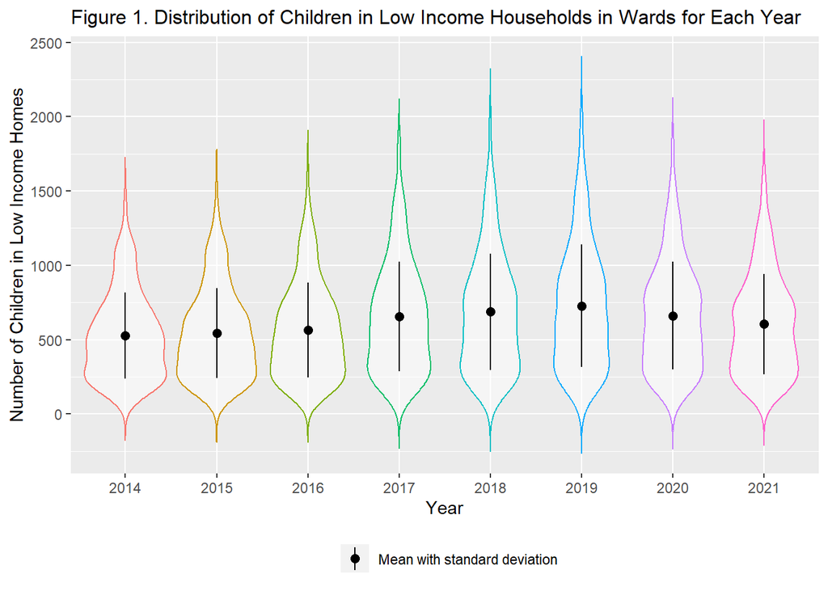

```r
# Make the distribution plot for number of children in low income homes across all years using violin plot
ggplot(children_low_income_new, aes(x=year, y=children, fill=children)) +
  geom_violin(trim=FALSE, alpha = 0.5, aes(color=year)) +
  stat_summary(fun.data=mean_sdl, fun.args = list(mult=1), color="black", aes(shape="Mean with standard deviation")) +
  labs(x="Year", y="Number of Children in Low Income Homes", title = "Figure 1. Distribution of Children in Low Income Households in Wards for Each Year") +
  guides(col="none") +
  theme(legend.position="bottom", legend.title=element_blank(), plot.title = element_text(size = 12))
```

We create violin plot to see the distribution of children in low income households in wards for each year.

### A t-test comparing earliest and latest year

```r
# Filter the dataset to include only data in year 2014 and 2021
children_low_income_for_ttest <- filter(children_low_income_new, (year%in%c("2014","2021")))
```

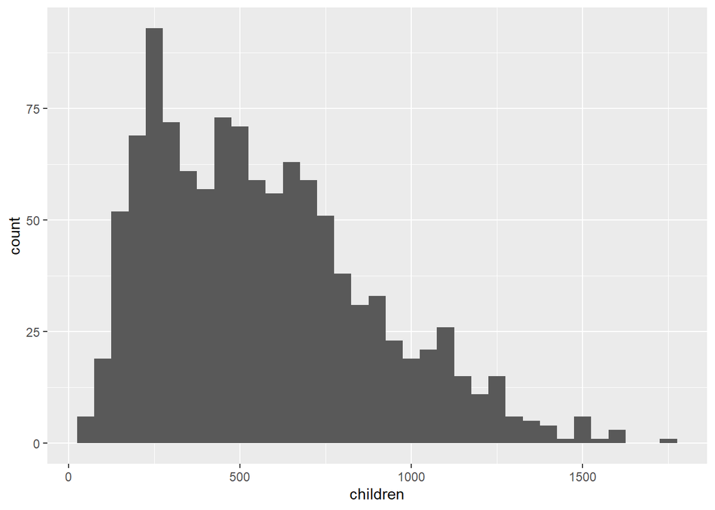

```r
# Use histogram to see if the distribution of the data is normal or not
ggplot(children_low_income_for_ttest) + geom_histogram(aes(children), binwidth=50)
```

The histogram shows that the data year 2014 and 2021 is a little bit positive skew but we carry on to use t-test as requested. Since most of the data are distributed < 1000, we do not have to remove the outlier numbers.

```r
# Perform t-test for data across all years
t.test(children~year, data=children_low_income_for_ttest)
```

```
##
##  Welch Two Sample t-test
##
## data:  children by year
## t = -4.0215, df = 1095.2, p-value = 6.18e-05
## alternative hypothesis: true difference in means between group 2014 and group 2021 is not equal to 0
## 95 percent confidence interval:
##  -112.4091  -38.6873
## sample estimates:
## mean in group 2014 mean in group 2021
##           528.3214           603.8696
```

```r
# Conduct estimation approach
m_children_low_income_by_year <- lm(children~year, data=children_low_income_for_ttest)
m_children_low_income_by_year_emm <- emmeans(m_children_low_income_by_year, ~year)
m_children_low_income_by_year_contrast <- confint(pairs(m_children_low_income_by_year_emm))
m_children_low_income_by_year_contrast
```

```
##  contrast            estimate   SE   df lower.CL upper.CL
##  year2014 - year2021    -75.5 18.8 1118     -112    -38.7
##
## Confidence level used: 0.95
```

# Section 2 (Report)

This report is presenting specifically the data of children living in low income households and intended to be used by the policy makers or local government in London. The dataset used in this report is taken from 2014 to 2021 (8 years).

In the beginning, we summarize the dataset into a table that showing the average, standard deviation, minimum number, and maximum number of children across all years and wards for every borough in London.

Table 1. Children in Low Income Households by Borough

| Borough | Average | Standard_Deviation | Minimum | Maximum |
| --- | --- | --- | --- | --- |
| Barking and Dagenham | 987 | 259 | 551 | 1750 |
| Barnet | 588 | 340 | 116 | 1807 |
| Bexley | 506 | 246 | 174 | 1469 |
| Brent | 707 | 280 | 249 | 1578 |
| Bromley | 390 | 210 | 113 | 1062 |
| Camden | 451 | 268 | 78 | 1373 |
| City of London | 26 | 31 | 5 | 156 |
| Croydon | 570 | 315 | 48 | 1508 |
| Ealing | 639 | 313 | 128 | 1327 |
| Enfield | 738 | 408 | 193 | 1895 |
| Greenwich | 839 | 407 | 211 | 1723 |
| Hackney | 697 | 288 | 231 | 1803 |
| Hammersmith and Fulham | 315 | 199 | 45 | 1042 |
| Haringey | 634 | 407 | 95 | 1691 |
| Harrow | 440 | 179 | 156 | 909 |
| Havering | 516 | 276 | 152 | 1405 |
| Hillingdon | 552 | 336 | 117 | 1416 |
| Hounslow | 599 | 252 | 141 | 1230 |
| Islington | 487 | 149 | 265 | 937 |
| Kensington and Chelsea | 146 | 134 | 23 | 557 |
| Kingston upon Thames | 236 | 111 | 69 | 665 |
| Lambeth | 584 | 202 | 212 | 1247 |
| Lewisham | 729 | 258 | 351 | 1570 |
| Merton | 379 | 269 | 38 | 1055 |
| Newham | 1213 | 250 | 575 | 1987 |
| Redbridge | 689 | 323 | 133 | 1664 |
| Richmond upon Thames | 163 | 93 | 58 | 507 |
| Southwark | 563 | 278 | 108 | 1279 |
| Sutton | 329 | 153 | 122 | 802 |
| Tower Hamlets | 1035 | 449 | 218 | 2094 |
| Waltham Forest | 797 | 256 | 269 | 1448 |
| Wandsworth | 392 | 259 | 85 | 1429 |
| Westminster | 259 | 228 | 16 | 853 |

Based on the Table 1, for the past 8 years, Newham has the highest average number of children living in low income households (1213 children), where Tower Hamlets has the highest number of children living in low income households with 2094 children. Borough with the lowest number of children living in low income households is City of London with only 5 children.

Initially, there are 33 boroughs in the raw data. But, as per request, we have excluded 5 boroughs deemed to be unusual, which are:

1. City of London
2. Kensington and Chelsea
3. Kingston upon Thames
4. Richmond upon Thames
5. Westminster

We did not include these 5 boroughs into our data processing and visualisation. We used 28 boroughs with 4480 observations from 2014 to 2021 for analysis.

Here, we have created a visualisation using violin plot to show the distribution of children in low income households in wards for each year.

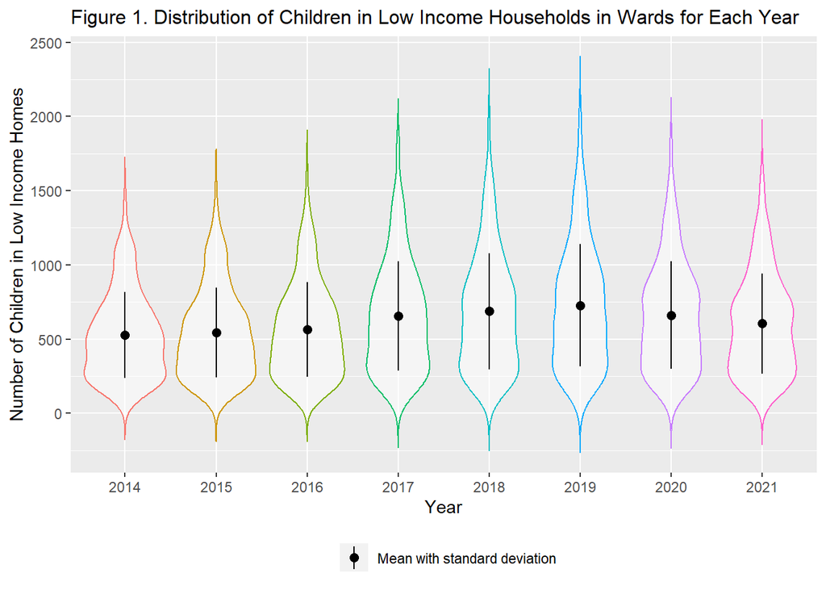

Based on the plot in Figure 1, the trend is up and down. The average number of children living in low income households was increasing from 2014 to 2019 but it was lowering down in 2020 and 2021. The number of children in low income households distributed around the mean in 2014, but it slightly distributed further away from 2015 until 2019. The number of children in low income households was starting to distribute near the mean again in 2020.

By using t-test to compare the dataset in the earliest year (2014) and the latest year (2021), we found that the mean of children in low income households in 2014 is 528 and the mean of children in low income households in 2021 is 603. The mean of children is significantly higher for year 2021, Welch $t(1095)=-4.02$, $p<.0001$, with a difference of 75, 95% confidence interval [-112 - -38.7].

The analysis conclusions using t-test in this report contain shortcomings that need to be improved. The data used for t-test can be considered positively skew distributed. Even though the majority of data lies < 1000, there are some data having a number > 1000. This makes the t-test result is potentially biased and we should be cautious to interpret the data with a more appropriate analysis method.